# Possession to Victory Analysis

[figure not shown]

```r
library(pander)
library(car)
library(DT)
library(mosaic)
library(tidyverse)
library(plotly)
library(ggplot2)
MLS <- read.csv("../Data/MLS Data.csv", header=TRUE)
View(MLS)
```

## If We Have It, They Cannot Score

There is a widely believed theory in soccer that the longer you have the ball the less opportunity your opponents have to score which should increase your chances of drawing or perhaps winning the game. The amount of time a team has control of the ball is referred to as ‘possession’. Possession is measured in %. For example, if a team has 70% possession then they controlled the ball for 70% of the game.

This analysis, though only analyzing data from one soccer league, proposes an explanation to this theory.

Now, this is not possible because a team either wins, loses or ties a match. However, we can inspect further to identify a possible correlation between if a team increases their possession of the ball, are they more likely to win more games.

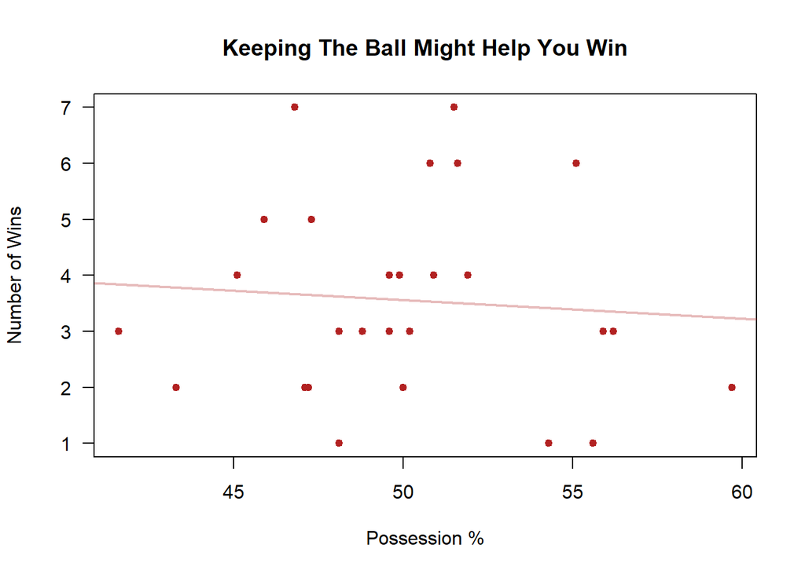

```r
p <- plot(Win ~ Possession, data=MLS, pch=20, col="firebrick", cex=1.2, las=1,
     xlab="Possession %", ylab="Number of Wins",
     main="Keeping The Ball Might Help You Win")

mls.lm <- lm(Win ~ Possession, data=MLS)
abline(mls.lm, lwd=2, col=rgb(.689,.133,.133, .3))
abline(h=seq(0,120,20), v=seq(5,25,5), lty=2, col=rgb(.2,.2,.2,.2))
```

```r
ggplotly(p)
```

## Analysis Details

A regression was performed in R to obtain the above results. The code and output of the regression is included below. The model assumed by the regression analysis was
$$\underbrace{Y_i}_\text{Number of Wins} = \overbrace{\beta_0}^\text{y-int} + \overbrace{\beta_1}^\text{slope} \underbrace{X_i}_\text{Possession%} + \epsilon_i \quad \text{where} \ \epsilon_i \sim N(0, \sigma^2)$$

**Summary of the Regression**

```r
mls.lm <- lm(Win ~ Possession, data=MLS)
pander(summary(mls.lm))
```

|  | Estimate | Std. Error | t value | Pr(>\|t\|) |
| --- | --- | --- | --- | --- |
| **(Intercept)** | 5.214 | 4.232 | 1.232 | 0.2294 |
| **Possession** | -0.03311 | 0.08423 | -0.3931 | 0.6976 |

Fitting linear model: Win ~ Possession

| Observations | Residual Std. Error | $R^2$ | Adjusted $R^2$ |
| --- | --- | --- | --- |
| 27 | 1.791 | 0.006144 | -0.03361 |

There does not appear to be enough evidence of a relationship. Assuming the relationship is linear, the equation of the fitted line shown in the plot above is

$$\underbrace{\hat{Y}_i}_\text{Mean Num. of Wins} = 5.214 -0.033 \underbrace{X_i}_\text{Possessionn%}$$

$$H_0: \beta_1^\text{possession} = 0$$
$$H_a: \beta_1^\text{possession} \neq 0$$

### Interpretation

While the effectiveness of using a linear model for this analysis is evaluated below, we can interpret what the results we have gained actually mean.

Does keeping the ball for longer increase a teams chances of winning a game? The answer is, in this situation, no. With the data gleaned from the Major League Soccer competition, keeping the ball does not increase your chances of winning more games.The null hypothesis stated at the beginning of the analysis is:
$$H_0: \beta_1^\text{possession} = 0$$
Due to the p-value for $beta_1$ $(p = 0.6976)$ we will fail to reject the null, which is to continue to believe the null. In other words, $possession$ does not affect the number of matches a soccer team wins.

As a soccer fan, I have seen this case to be true. When a team naturally dominates the ball it forces the opposition team to keep every player behind the ball to defend, or ‘parking the bus’ as is known in the soccer world. Space on the field then becomes very limited and team dominating the ball struggle to make attacking plays. Furthermore, this can often frustrate the team dominating the ball and leave this team prone to a counterattack (a turn over in possession) in which their players are out of position and become vulnerable to conceding.

### Validation of the Model Appropriateness

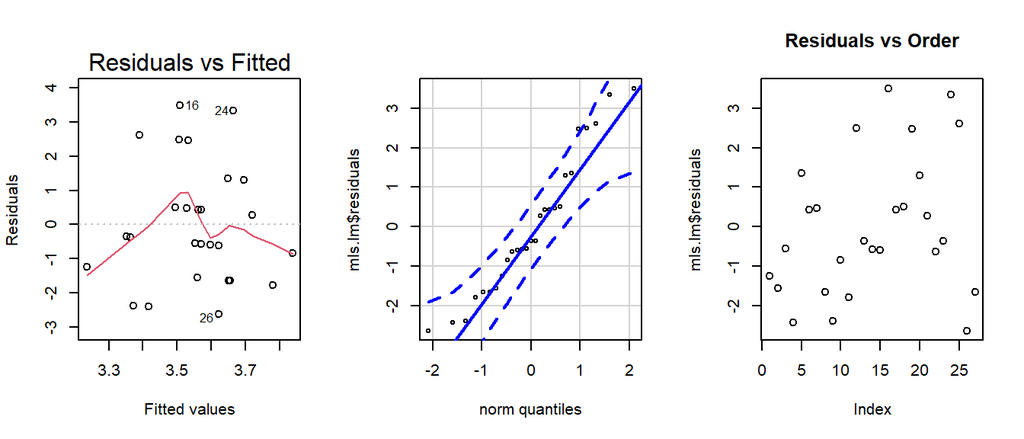

```r
par(mfrow=c(1,3))
plot(mls.lm, which=1)
qqPlot(mls.lm$residuals, id=FALSE)
plot(mls.lm$residuals, main="Residuals vs Order")
```

### The Data

Here is the data from the experiment for those interested. The data was obtained from the following reputable source: https://fbref.com/en/comps/22/Major-League-Soccer-Stats

```r
datatable(MLS)
```

|  | Squad | Win | Possession |
| --- | --- | --- | --- |
| 1 | Atlanta Utd | 2 | 59.7 |
| 2 | Austin FC | 2 | 50 |
| 3 | CF Montréal | 3 | 50.2 |
| 4 | Chicago Fire | 1 | 54.3 |
| 5 | Colorado Rapids | 5 | 47.3 |
| 6 | Columbus Crew | 4 | 49.6 |
| 7 | D.C. United | 4 | 50.9 |
| 8 | FC Cincinnati | 2 | 47.1 |
| 9 | FC Dallas | 1 | 55.6 |
| 10 | Houston Dynamo | 3 | 41.6 |

[output cut: 17 more lines]